##### AI TECH - Akademia Innowacyjnych Zastosowań Technologii Cyfrowych. Programu Operacyjnego Polska Cyfrowa na lata 2014-2020

# Przykład 1 DO LABORATORIUM 4

# Metoda gradientu prostego, perceptron

# Tomasz Neumann

### Stochastyczny gradient prosty, batch i mini-batch

[figure not shown]

Projekt współfinansowany ze środków Unii Europejskiej w ramach Europejskiego Funduszu Rozwoju Regionalnego Program Operacyjny Polska Cyfrowa na lata 2014-2020, Oś Priorytetowa nr 3 "Cyfrowe kompetencje społeczeństwa" Działanie nr 3.2 "Innowacyjne rozwiązania na rzecz aktywizacji cyfrowej" Tytuł projektu: „Akademia Innowacyjnych Zastosowań Technologii Cyfrowych (AI Tech)”

# 1. Przykład 1

Metoda gradientu prostego (*gradient descent*) polega na wielokrotnym poprawieniu wartości parametrów w celu zminimalizowania funkcji kosztu. W metodzie tej na początku inicjujemy losowymi wartościami wektor parametrów $\theta$, a następnie za pomocą 'małych kroków' dążymy do zredukowania funkcji kosztu (np. wspomnianej w poprzednim przykładzie MSE), aż do momentu uzyskania zbieżności algorytmu z wartością minimalną tejże funkcji. W metodzie tej ważny jest rozmiar poszczególnych 'kroków', który opisywany jest za pomocą hiperparametru określanego jako współczynnik uczenia (*learning rate*). Przy wyborze tej wartości należy mieć na uwadze, aby nie była zbyt mała, gdyż algorytm wówczas będzie potrzebował bardzo dużo przebiegów do osiągnięcia oczekiwanej wartości, a co za tym idzie będzie to czasochłonne. Zbyt duża wartość może doprowadzić natomiast do sytuacji w której nastąpi przeoczenie minimum, jednocześnie znajdująć się po drugiej stronie tej doliny, nawet z wartością większą niż początkową, co w konsekwencji może doprowadzić do rozbieżności pracy algorytmu, a co za tym idzie, nie będzie mozna znaleźć rozwiązania. Należy także mieć na uwadze wybór funkcji kosztu do minimalizacji, gdyż nie wszystkie mają 'ładny kształ' , posiadając minima lokalne, minima globalne i wypłaszczenia, co w przypadku różnych losowych inicjacji poczatkowych, może nie doprowadzić do osiągnięcia globalnego minimum. W uczeniu maszynowym metoda spadku gradientu jest techniką optymalizacji używaną do obliczania parametrów modelu (współczynników i ich odchyleń standardowych) dla algorytmów takich jak regresja liniowa, regresja logistyczna, sieci neuronowe itp. W tej technice wykonuje się wielokrotnie iteracje prze zestaw uczący, aktualizując parametry modelu zgodnie z gradientem błędu w odniesieniu do zbioru uczacego. W zależności od wielkości zbioru danych treningowych branych pod uwagę podczas aktualizacji parametrów modelu, możemy wyróżnić trzy podejścia:

**Batch Gradient Descent** - parametry są aktualizowane w oparciu o cały zestaw danych uczących (wykonanie pojedynczej aktualizacji zajmuje dużo czasu);

**Stochastic Gradient Descent** - parametry są aktualizowane po obliczeniu gradientu błędu w oparciu o pojedynczy przykład treningowy (zapętlenie zestawu uczącego, a tym samym nie można wykorzystać w pełni prędkości obliczeń związanej z wektoryzacją kodu);

**Mini-Batch Gradient Descent** - parametry są aktualizowane po obliczeniu gradientu błędu w odniesieniu do podzbioru zbioru uczącego (może dokonywać szybkich aktualizacji wykorzystując także potencjał wektoryzacji kodu, jednak należy uważać na szybkie i chwilowe aktuaalizacje parametrów modelu w zalezności od przyjętego rozmiaru paczki danych).

Tak więc, *Mini-Batch Gradient Descent* stanowi kompromis między szybką zbieżnością a zakłóceniami związanymi z aktualizacją gradientu, co czyni go bardziej elastycznym i niezawodnym algorytmem.

W celu sprawdzenia tych trzech podejść można napisać prostą implementację kodu, który to zrelizuje za pomocą bibliotek numpy oraz matplotlib. Stworzone zostaną także dane syntetyczne do regresji liniowej (8000 przykładów danych, z których każdy ma po dwa atrybuty/cechy na podstawie wielowymiarowego rozkładu normalnego), oraz ich wizualizację. W tym kroku zostanie także dokonany podział całego zbioru danych na dane treningowe i testowe w stosunku 9:1.

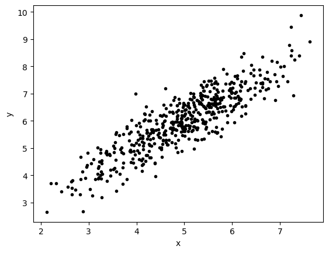

```
Liczba danych treningowych =  7200
Liczba danych testowych =  800
```

```python
# Import podstawowych bibliotek języka Python
import numpy as np  # operacje numeryczne
import matplotlib  # wykresy i ich ustawienia
import matplotlib.pyplot as plt  # tworzenie wykresu
import time

# stworzenie danych
mean = np.array([5.0, 6.0])
cov = np.array([[1.0, 0.95], [0.95, 1.2]])
#stworzenie danych losowych z wielowymiarowego rozkładu normalnego
data = np.random.multivariate_normal(mean, cov, 8000)
# wizualizacja danych
plt.scatter(data[:500, 0], data[:500, 1], c = 'black', marker = '.')
plt.xlabel('x')
plt.ylabel('y')
plt.show()

# podział danych na treningowe i testowe
data = np.hstack((np.ones((data.shape[0], 1)), data))
## współczynnik podziału
split_factor = 0.90
split = int(split_factor * data.shape[0])

X_train = data[:split, :-1]
y_train = data[:split, -1].reshape((-1, 1))
X_test = data[split:, :-1]
y_test = data[split:, -1].reshape((-1, 1))

print("Liczba danych treningowych = % d"%(X_train.shape[0]))
print("Liczba danych testowych = % d"%(X_test.shape[0]))
```

W kojenym kroku zostanie pokazany kod implementujący regresję liniową przy użyciu 'mini-paczek'. W tym przypadku funkcja gradientDescent() jest główną, a pozostałe są tylko pomocniczymi. Funkcja główna inicjuje parametry, oblicza najlepszy zestaw parametrów dla modelu i zwraca te parametry wraz z listą zawierającą historię błędów podczas aktualizowania parametrów.

```python
# regresja liniowa przy użyciu "mini-batch" w metodzie spadku gradientu
# funkcja do wyliczania predykcji
def hypothesis(X, theta):
    return np.dot(X, theta)

# funkcja wyliczająca gradient
def gradient(X, y, theta):
    h = hypothesis(X, theta)
    grad = np.dot(X.transpose(), (h - y))
    return grad

# funkcja do wyliczania błędu i aktualnej wartości theta
def cost(X, y, theta):
    h = hypothesis(X, theta)
    J = np.dot((h - y).transpose(), (h - y))
    J /= 2
    return J[0]

# funkcja tworzącą listę mini-batches
def create_mini_batches(X, y, batch_size):
    mini_batches = []
    data = np.hstack((X, y))
    np.random.shuffle(data)
    n_minibatches = data.shape[0] // batch_size
    i = 0

    for i in range(n_minibatches + 1):
        mini_batch = data[i * batch_size:(i + 1)*batch_size, :]
        X_mini = mini_batch[:, :-1]
        Y_mini = mini_batch[:, -1].reshape((-1, 1))
        mini_batches.append((X_mini, Y_mini))
    if data.shape[0] % batch_size != 0:
        mini_batch = data[i * batch_size:data.shape[0]]
        X_mini = mini_batch[:, :-1]
        Y_mini = mini_batch[:, -1].reshape((-1, 1))
        mini_batches.append((X_mini, Y_mini))
    return mini_batches

# funkcja główna wykonująca stochastyczny spadek gradientu z mini-batches
def gradientDescent(X, y, learning_rate = 0.001, batch_size = 8):
    theta = np.zeros((X.shape[1], 1))
    error_list = []
    max_iters = 3
    for itr in range(max_iters):
        mini_batches = create_mini_batches(X, y, batch_size)
        for mini_batch in mini_batches:
            X_mini, y_mini = mini_batch
            theta = theta - learning_rate * gradient(X_mini, y_mini, theta)
            error_list.append(cost(X_mini, y_mini, theta))

    return theta, error_list
```

W tym kroku nastapi wywołanie metody głównej, która obliczy parametry modelu oraz zostaną zwizualizowane zmiany funkcji błędu.

```
(7200, 2)
Czas wykonania: 0.5139646530151367
Bias =  [0.76822179]
Coefficients =  [[1.02578981]]
```

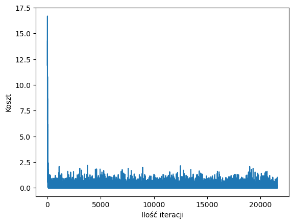

```python
start = time.time()
print(X_train.shape)
theta, error_list = gradientDescent(X_train, y_train, learning_rate = 0.001, batch_size = 1)
end = time.time()
print(f"Czas wykonania: {end-start}")
print("Bias = ", theta[0])
print("Coefficients = ", theta[1:])

# wizualizacja spadku gradientu z mini-batches
plt.plot(error_list)
plt.xlabel("Ilość iteracji")
plt.ylabel("Koszt")
plt.show()
```

Ostatecznie należy przeprowadzić predekcję na zbiorze testowym oraz obliczyć średni błąd bezwględny z wykonanych prognoz.

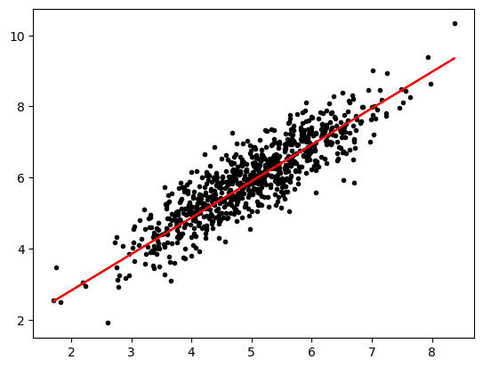

```
MAE =  0.43251308390507825
MSE =  0.2940055433315718
```

```python
# predykcja na zbiorze testowym
y_pred = hypothesis(X_test, theta)
plt.scatter(X_test[:, 1], y_test[:, ], c = "black", marker = '.')
plt.plot(X_test[:, 1], y_pred, color = 'red')
plt.show()

# wyliczenie MAE z predykcji
error = np.sum(np.abs(y_test - y_pred) / y_test.shape[0])
print("MAE = ", error)
mse = np.square(np.subtract(y_test, y_pred)).mean()
print("MSE = ", mse)
```

# Zadania do wykonania

**Zadanie 1**

Przeprowadź i przeanalizuj eksperymenty dla różnych wartości mini-batches, tak aby przetestować podejścia opisane we wstępie tego notatnika.

```python
import numpy as np
import pandas as pd


def prepare_data(seed=42):
    rng = np.random.default_rng(seed)
    data = rng.multivariate_normal([5.0, 6.0], [[1.0, 0.95], [0.95, 1.2]], 8000)
    data = np.hstack((np.ones((data.shape[0], 1)), data))
    split = int(0.9 * data.shape[0])
    return data[:split, :-1], data[:split, -1:], data[split:, :-1], data[split:, -1:]


def run(batch_size, learning_rate=0.001, epochs=3, seed=123):
    Xtr, ytr, Xte, yte = prepare_data()
    theta = np.zeros((Xtr.shape[1], 1))
    rng = np.random.default_rng(seed)
    updates = 0
    last_cost = np.nan

    for _ in range(epochs):
        shuffled = np.hstack((Xtr, ytr))
        rng.shuffle(shuffled)
        for start in range(0, len(shuffled), batch_size):
            batch = shuffled[start:start + batch_size]
            Xb, yb = batch[:, :-1], batch[:, -1:]
            theta -= learning_rate * gradient(Xb, yb, theta)
            last_cost = float(np.asarray(cost(Xb, yb, theta)).ravel()[0])
            updates += 1
            if not np.isfinite(last_cost):
                break

    y_pred = hypothesis(Xte, theta)
    mae = float(np.mean(np.abs(yte - y_pred)))
    mse = float(np.mean((yte - y_pred) ** 2))
    return batch_size, updates, mae, mse


batch_results = pd.DataFrame(
    [run(bs) for bs in [1, 57, 64, 256, 7200]],
    columns=["batch_size", "updates", "MAE", "MSE"],
)
print(batch_results.to_string(index=False, float_format=lambda x: f"{x:.6g}"))
```

```
 batch_size  updates         MAE          MSE
          1    21600    0.435149     0.293177
         57      381    0.438995     0.302666
         64      339    0.434501     0.292776
        256       87 3.98737e+62 1.63864e+125
       7200        3 4.35851e+07  1.97094e+15
```

**Wnioski do zadania 1**

Najlepszy wynik uzyskał `batch_size=64` -> `MAE=0.435`, `MSE=0.293`.

`batch_size=57` (indeks `193257`) -> też dało dobre wyniki -> minimalnie większy błąd (`MSE=0.303`).

SGD (`batch_size=1`) osiągnął podobny błąd do stabilnych mini-batchy (`MSE=0.293`), ale potrzebował aż `21600` aktualizacji.

Zbyt duże paczki (`256` i pełny batch `7200`) rozbiegły się (bardzo duży błąd) przy `learning_rate=0.001`, więc w tych ustawieniach nie są one dobrym wyborem.

**Zadanie 2**

Przeprowadź i przeanalizuj eksperymenty dla różnych współczynników uczenia przy ustalonej wartości mini-batches (liczba mini-batches składająca się z dwóch ostatnich cyfr numeru albumu).

Indeks: `193257` -> `batch_size=57`.

```python
album_number = 193257
fixed_batch_size = album_number % 100
learning_rates = [0.0001, 0.0005, 0.001, 0.002, 0.005]

lr_results = pd.DataFrame(
    [run(fixed_batch_size, learning_rate=lr) for lr in learning_rates],
    columns=["batch_size", "updates", "MAE", "MSE"],
)

lr_results.insert(0, "learning_rate", learning_rates)

print(lr_results.to_string(index=False, float_format=lambda x: f"{x:.6g}"))
```

```
 learning_rate  batch_size  updates          MAE          MSE
        0.0001          57      381     0.458617     0.324528
        0.0005          57      381     0.444191     0.305041
         0.001          57      381     0.438995     0.302666
         0.002          57      381 9.64212e+117 9.64621e+235
         0.005          57      186 1.46991e+154          inf
```

**Wnioski do zadania 2**

Dla `batch_size=57` najlepszy z przetestowanych stabilnych wyników dał `learning_rate=0.001` (`MAE=0.439`, `MSE=0.303`).

Mniejsze wartości learning rate rodzaju 0.0001 i 0.0005 były stabilne. Miały one minimalnie większy błąd.

Po zwiększeniu współczynnika uczenia do `0.002` algorytm już się rozbiegł -> bardzo duże `MSE`. Dla `0.005` podobnie -> MSE wyniósł `inf` :)

Zatem w tych eksperymentach sensownym wyborem jest więc `learning_rate=0.001`.

Współczynnik uczenia decyduje nie tylko o szybkości uczenia, ale też o stabilności. Dla zbyt małych wartości model uczy się wolno i kończy z większym błędem, a dla zbyt dużych wartości pojawia się rozbieżność, bardzo duże błędy albo wartości inf.